title: R_GIS_01 author: Derek Ding date: “2023-02-01” output: html_document: code_folding: show

# Learning Notes for R_GIS Chapter 1

This is the first chapter of the notes for using R to process and analyze GIS data. There aretwo components in this first chapter of the series of notes: rmd review and R-GIS introduction. Most of the contents are from the following online resources:

1. [Fixing the RTools Error Message in R](https://www.youtube.com/watch?v=KsbTXYKrocQ)
2. [Best practices for reporting with R markdown](https://appsilon.com/r-markdown-reporting-best-practices/)
3. [YAML in RMD](https://zsmith27.github.io/rmarkdown_crash-course/lesson-4-yaml-headers.html)
4. [This is the code book that I am following](https://geocompr.robinlovelace.net/spatial-class.html#intro-sf)

Most of the contents cited for this course note are created under the MIT creative commons license. Please send messages via GitHub in case of any potential IP violations. Many thanks to the active members of the R-GIS online communities!

Now, let’s begin our journey!

## Pre-start: rmd quick review and walk through

1. Specifying a file dir path in rmd:use `D:\Downloads`
2. add links in rmd:
3. Hierarchical bullet points:
- un-ordered list
  - sub-item 1
  - sub-item 2
    - sub-sub-item 1
4. **Bold** and **Bold**
5. *Italics* and *Italics*
6. Tables: mid: `|:------------------:|`  
   left:`|:------------------|`  
   right:`|------------------:|`  
   Example:

| Option | Description |
| --- | --- |
| `rows.print` | Maximum rows to print per page. |
| `max.print` | Maximum rows in the table (defaults to 1000). |
| `cols.print` | Maximum columns in the table (defaults to 10). |
| `rownames.print` | Print row names as part of the table. |

7. New line: `<br>`
8. More on: [rmd Cheat Sheet](https://www.rstudio.com/wp-content/uploads/2015/02/rmarkdown-cheatsheet.pdf)

## Section 1. R Packages for GIS Analysis

We need to install GIS-R and basic data wrangling packages for R.

### Section 1.1 Installing the packages

Here we go ahead and install the following GIS-R packages:

```r
#install.packages("sf")
#install.packages("terra")
#install.packages("spData")
#install.packages("spDataLarge", repos = "https://nowosad.r-universe.dev")
#install.packages("raster", dependencies = TRUE)
# install.packages("sp")
```

**Other Useful Packages:** Also installed ggplot (included in tidyverse) and dplyr packages for quick stat visualization and data wrangling.

**Rtools Warning Messages:** While installing the packages, the terminal returned warning messages about not having rtools package.

```r
#install.packages("rtools")
#install.packages("tidyverse")
#install.packages("dplyr")
```

These warning messages are annoying, have installed the rtools43 package to prevent similar error messages from showing up in the future, the message pops up possibly due to the compatibility of different packages to our existing build of R. If the installation did not work, come back to this thread: [Fixing the RTools Error Message in R](https://www.youtube.com/watch?v=KsbTXYKrocQ) Note: * This happens only if we are trying to install packages built with C or FORTRAN. ** need to add the “C:” to Path

### Section 1.2 Loading the R libraries needed for this practice

```r
#this section: we set error out put to TRUE
#library(terra)
#library(sf)      # classes and functions for raster data
#library(spData)        # load geographic data
#library(spDataLarge)   # load larger geographic data
```

## Section 2. Data Models

Which to use? The answer likely depends on your domain of application:

**Vector** data tends to dominate the social sciences because human settlements tend to have discrete borders.

**Raster** dominates many environmental sciences because of the reliance on remote sensing data.

There is much overlap in some fields and raster and vector datasets can be used together: ecologists and demographers, for example, commonly use both vector and raster data. Furthermore, it is possible to convert between the two forms. Whether your work involves more use of vector or raster datasets, it is worth understanding the underlying data model before using them, as discussed in subsequent chapters. This book uses sf and terra packages to work with vector data and raster datasets, respectively.

### Section 2.1 Vector Data

The geographic vector data model is based on points located within a coordinate reference system (CRS). Points can represent self-standing features (e.g., the l ocation of a bus stop) or they can be linked together to form more complex geometries such as lines and polygons. Most point geometries contain only two dimensions (3-dimensional CRSs contain an additional z value, typically representing height above sea level).

**Note:** The following message will appear: Linking to GEOS 3.9.3, GDAL 3.5.2, PROJ 8.2.1; sf_use_s2() is TRUE when you load “sf”, which shows the linkage of sf package to GEOS, GDAL, PROJ libraries. (what version of each sf is referring to)

```r
#library(sf)
#class(world)
#names(world)
#plot(world)
```

Some error messages appeared, installed the following dependency packages to help clear the errors.

```r
# install.packages(c("cowplot","googleway", "ggplot2", "ggrepel",
#                "ggspatial", "libwgeom", "sf", "rnaturalearth", "rnaturalearthdata",
# "rgeos"))
# install.packages("e1071")
```

Run the following code to open help on sf and sf1 packages:

```r
#library(sf)
#vignette(package = "sf") # see which vignettes are available
#vignette("sf1")          # an introduction to the package

#class(world)
#names(world)
#plot(world)
```

After installing all necessary packages, re-run the world codes:

```r
# library(sf)
# library("ggplot2")
# theme_set(theme_bw())
# library("sf")
# library("rnaturalearth")
# library("rnaturalearthdata")
# library(rgeos)
# world <- ne_countries(scale = "medium", returnclass = "sf")
# class(world)
# names(world)
# plot(world)
```

sf provides classes for geographic vector data and a consistent command-line interface to important low level libraries for geo-computation:

### Section 2.2 Simple Features

```r
# vignette(package = "sf")
# see which vignettes are available
#vignette("sf1")
# an introduction to the package
```

#### Sub-Section 2.2.1 More on SF packages

Here we combine our previous code blocks, and add some more sf functions for demo purposes. The following code blocks records and test the whol section 2.1

We need to load the dataframe object [world](https://cran.r-project.org/web/packages/spData/spData.pdf) from spData, rather than sf, loading fron sf with method `ne_countries` does not include the columns that we need.

use `sf::sf_use_s2(FALSE)` to switch off the spherical geometry (s2)

```r
library(sf)
sf::sf_use_s2(FALSE)
```

```
## Spherical geometry (s2) switched off
```

```r
library(ggplot2)
theme_set(theme_bw())
#library("sf")
library(rnaturalearth)
library(spData)
library(rgeos)
class(world)
```

```
## [1] "sf"         "tbl_df"     "tbl"        "data.frame"
```

```r
# This one loads from spData package:
world <- st_read(system.file("shapes/world.gpkg", package="spData"))
# This function loads partial data: which does not contain
#world_01 <- ne_countries(scale = "medium", returnclass = "sf")
class(world)
```

```
## [1] "sf"         "data.frame"
```

```r
names(world)
```

```
##  [1] "iso_a2"    "name_long" "continent" "region_un" "subregion" "type"
##  [7] "area_km2"  "pop"       "lifeExp"   "gdpPercap" "geom"
```

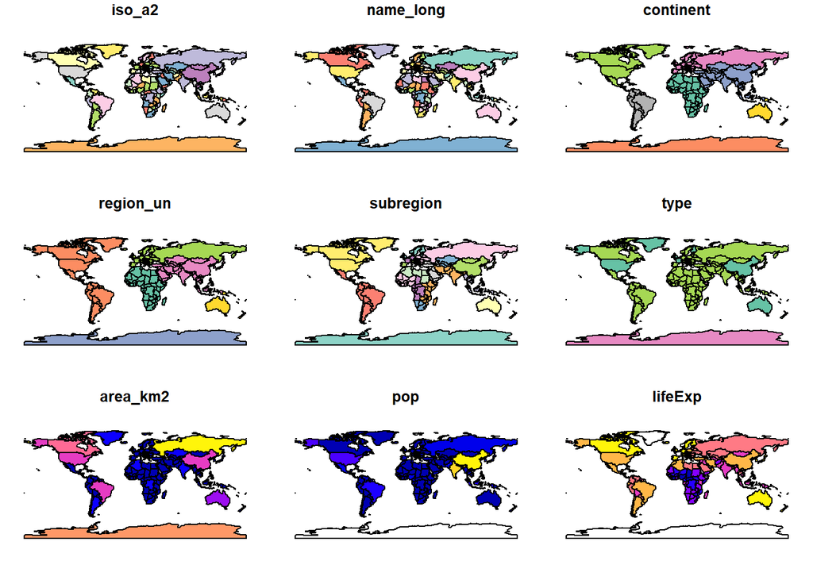

```r
plot(world)
```

```r
summary(world["lifeExp"])
```

```
##     lifeExp                 geom
##  Min.   :50.62   MULTIPOLYGON :177
##  1st Qu.:64.96   epsg:4326    :  0
##  Median :72.87   +proj=long...:  0
##  Mean   :70.85
##  3rd Qu.:76.78
##  Max.   :83.59
##  NA's   :10
```

Although we have only selected one variable for the summary() command, it also outputs a report on the geometry. This demonstrates the ‘sticky’ behavior of the geometry columns of sf objects, meaning the geometry is kept unless the user deliberately removes them, as we’ll see in Section 3.2. The result provides a quick summary of both the non-spatial and spatial data contained in world: the mean average life expectancy is 71 years (ranging from less than 51 to more than 83 years with a median of 73 years) across all countries.

```r
summary(world["lifeExp"])
```

```
##     lifeExp                 geom
##  Min.   :50.62   MULTIPOLYGON :177
##  1st Qu.:64.96   epsg:4326    :  0
##  Median :72.87   +proj=long...:  0
##  Mean   :70.85
##  3rd Qu.:76.78
##  Max.   :83.59
##  NA's   :10
```

#### Sub-Section 2.2.2 Data Types with Simple Features

SF objects are like a data frame for spatial data. They are easy to subset.

The code below shows how to returen an object containing only the first 2 rows and first three columns of the object ‘world’ which we have defined previously. The output includes geo metadata: Geometry type, Dimension, Bounding box and coordinate reference system information on the line beginning Geodetic CRS CRS information. It also contains a grometry column named geom here.

```r
world_mini = world[1:2, 1:3]
world_mini
```

```
## Simple feature collection with 2 features and 3 fields
## Geometry type: MULTIPOLYGON
## Dimension:     XY
## Bounding box:  xmin: -180 ymin: -18.28799 xmax: 180 ymax: -0.95
## Geodetic CRS:  WGS 84
##   iso_a2 name_long continent                           geom
## 1     FJ      Fiji   Oceania MULTIPOLYGON (((-180 -16.55...
## 2     TZ  Tanzania    Africa MULTIPOLYGON (((33.90371 -0...
```

Simple features is a widely supported data model that underlies data structures in many GIS applications including QGIS and PostGIS. A major advantage of this is that using the data model ensures your work is cross-transferable to other set-ups, for example importing from and exporting to spatial databases.

A more specific question from an R perspective is “why use the sf package when sp is already tried and tested”? There are many reasons (linked to the advantages of the simple features model):

- Fast reading and writing of data
- Enhanced plotting performance
- sf objects can be treated as data frames in most operations
- sf function names are relatively consistent and intuitive (all begin with st_)
- sf functions can be combined with the |> operator and works well with the tidyverse collection of R packages.
- sf’s support for tidyverse packages is exemplified by read_sf(), a function for importing geographic vector data covered in detail [here](https://geocompr.robinlovelace.net/read-write.html#iovec)

Unlike the function st_read(), which returns attributes stored in a base R data.frame (and which emits verbose messages, not shown in the code chunk below), read_sf() silently returns data as a tidyverse [tibble](https://tibble.tidyverse.org/).

```r
world_dfr = st_read(system.file("shapes/world.shp", package = "spData"))
world_tbl = read_sf(system.file("shapes/world.shp", package = "spData"))
class(world_dfr)
```

```
## [1] "sf"         "data.frame"
```

```
#> [1] "sf"         "data.frame"
```

```r
class(world_tbl)
```

```
## [1] "sf"         "tbl_df"     "tbl"        "data.frame"
```

```
#> [1] "sf"         "tbl_df"     "tbl"        "data.frame"
```

**Note:** GDAL information: Provides bindings to the ‘Geospatial’ Data Abstraction Library (‘GDAL’) (>= 1.11.4) and access to projection/transformation operations from the ‘PROJ’ library. Please note that ‘rgdal’ will be retired by the end of 2023, plan transition to sf/stars/‘terra’ functions using ‘GDAL’ and ‘PROJ’ at your earliest convenience.

#### Sub-Section 2.2.4 SF Geometry Tpyes

```r
world$geom
```

```
## Geometry set for 177 features
## Geometry type: MULTIPOLYGON
## Dimension:     XY
## Bounding box:  xmin: -180 ymin: -89.9 xmax: 180 ymax: 83.64513
## Geodetic CRS:  WGS 84
## First 5 geometries:
```

```
## MULTIPOLYGON (((-180 -16.55522, -179.9174 -16.5...
```

```
## MULTIPOLYGON (((33.90371 -0.95, 31.86617 -1.027...
```

```
## MULTIPOLYGON (((-8.66559 27.65643, -8.817828 27...
```

```
## MULTIPOLYGON (((-132.71 54.04001, -133.18 54.16...
```

```
## MULTIPOLYGON (((-171.7317 63.78252, -171.7911 6...
```

#### Sub-Section 2.2.5 SF Basic Map-Making

For compatibility purposes, we need to also use the spatial package, **“sp”** The code below, shows how we can convert sp objects to sf ones and vice versa:

```r
library(sp)
library(sf)

# from an sf object to sp
world_sp = as(world, "Spatial")

# from sp to sf
world_sf = st_as_sf(world_sp)
```

Let’s check out the differences between sp and sf objects

```r
# from an sf object to sp
world_sp[1,1]
```

[output not shown]

[output cut: 83 more lines]

[output not shown]

```r
world_sf[1,1]
```

```
## Simple feature collection with 1 feature and 1 field
## Geometry type: MULTIPOLYGON
## Dimension:     XY
## Bounding box:  xmin: -180 ymin: -18.28799 xmax: 180 ymax: -16.02088
## Geodetic CRS:  WGS 84
##   iso_a2                       geometry
## 1     FJ MULTIPOLYGON (((-180 -16.55...
```

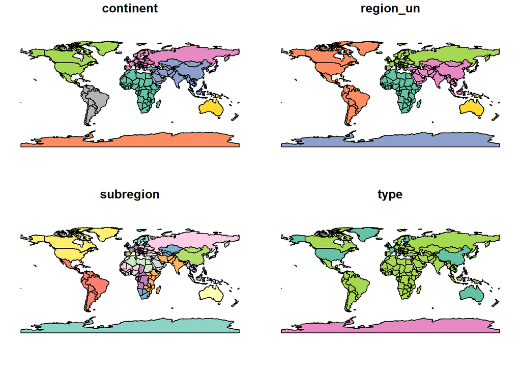

```r
plot(world[3:6])
```

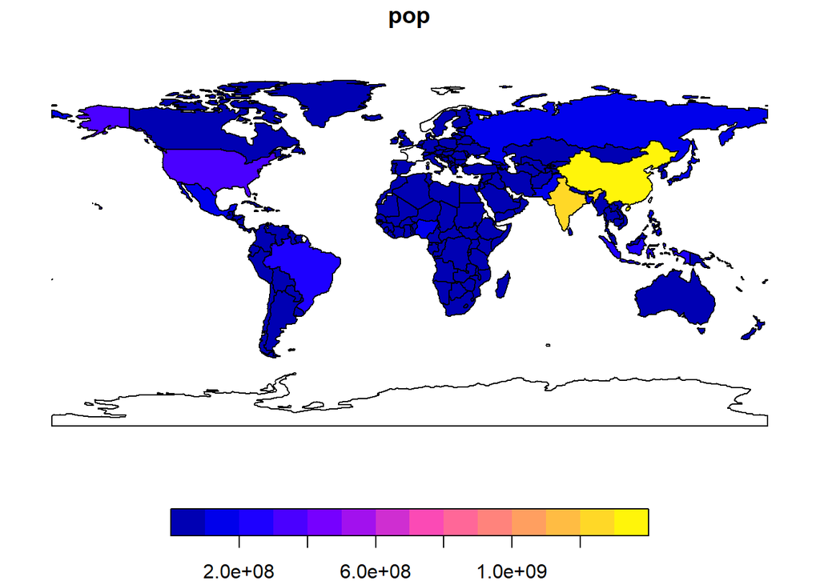

```r
plot(world["pop"])
```

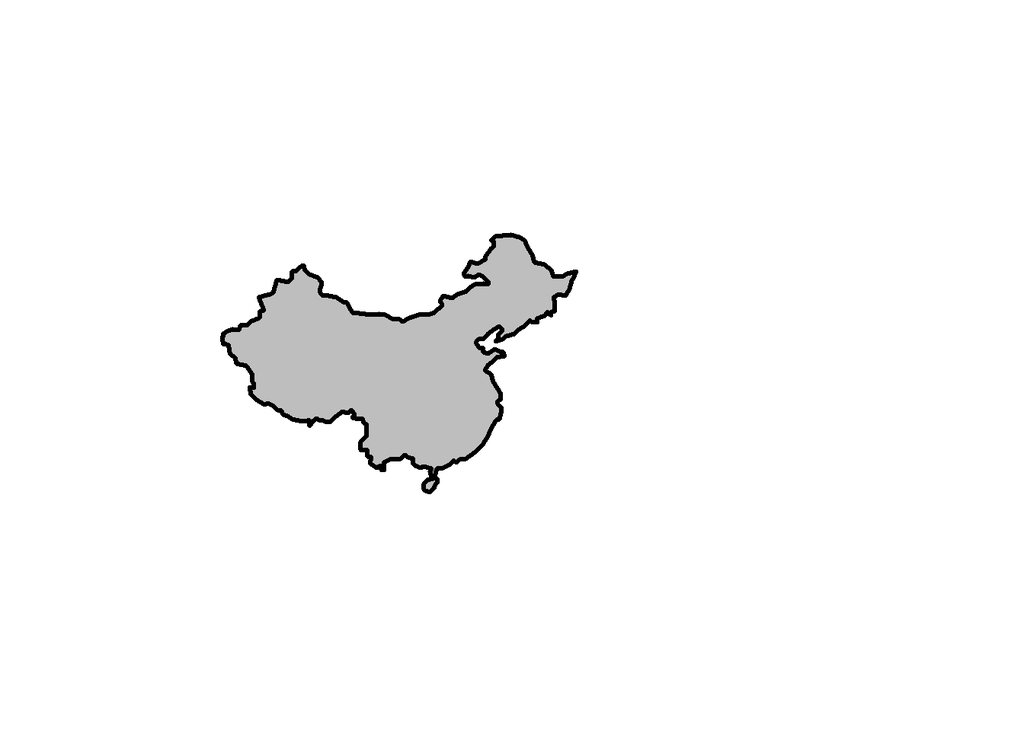

```r
chn= world[world$name_long == "China", ]
plot(st_geometry(chn), expandBB = c(0, 0.2, 0.1, 1), col = "gray", lwd = 3)
```

```r
plot(st_geometry(world_asia), add = TRUE)
```

[output not shown]

## Section 3